# Tidy Data and Reshaping Data

Jake Rozran

2022-03-30

# What is Tidy Data?

First, let’s install and load a new package, which lets us read data from google sheets directly.

```r
# install.packages("googlesheets4")
library(googlesheets4)
```

Then - let’s grab a dataset from Gapminder (this key is in [Google Drive](https://docs.google.com/document/d/1zq1jd9SoViPaTgA31uwvTk3Sg3UeUieWIaTdDjhYSAE/edit)).

```r
hiv_key <- "1kWH_xdJDM4SMfT_Kzpkk-1yuxWChfurZuWYjfmv51EA"
hiv <- read_sheet(hiv_key)
```

[output not shown]

[output not shown]

[output not shown]

[output not shown]

```
## ✓ Reading from "indicator hiv estimated prevalence% 15-49".
```

```
## ✓ Range 'Data'.
```

```r
hiv
```

```
## # A tibble: 275 × 34
##    `Estimated HIV Pre…`  `1979` `1980` `1981` `1982` `1983` `1984` `1985` `1986`
##    <chr>                  <dbl>  <dbl>  <dbl>  <dbl>  <dbl>  <dbl>  <dbl>  <dbl>
##  1 Abkhazia             NA          NA     NA     NA     NA     NA     NA     NA
##  2 Afghanistan          NA          NA     NA     NA     NA     NA     NA     NA
##  3 Akrotiri and Dhekel… NA          NA     NA     NA     NA     NA     NA     NA
##  4 Albania              NA          NA     NA     NA     NA     NA     NA     NA
##  5 Algeria              NA          NA     NA     NA     NA     NA     NA     NA
##  6 American Samoa       NA          NA     NA     NA     NA     NA     NA     NA
##  7 Andorra              NA          NA     NA     NA     NA     NA     NA     NA
##  8 Angola                0.0265     NA     NA     NA     NA     NA     NA     NA
##  9 Anguilla             NA          NA     NA     NA     NA     NA     NA     NA
## 10 Antigua and Barbuda  NA          NA     NA     NA     NA     NA     NA     NA
## # … with 265 more rows, and 25 more variables: `1987` <dbl>, `1988` <lgl>,
## #   `1989` <lgl>, `1990` <dbl>, `1991` <dbl>, `1992` <dbl>, `1993` <dbl>,
## #   `1994` <dbl>, `1995` <dbl>, `1996` <dbl>, `1997` <dbl>, `1998` <dbl>,
## #   `1999` <dbl>, `2000` <dbl>, `2001` <dbl>, `2002` <dbl>, `2003` <dbl>,
## #   `2004` <dbl>, `2005` <dbl>, `2006` <dbl>, `2007` <dbl>, `2008` <dbl>,
## #   `2009` <list>, `2010` <list>, `2011` <list>
```

This data is NOT tidy. Why is it not tidy?

Each row has multiple datapoints or observations.

It is “easy” to see the trend in this data… just following a row. However, each row does not refer to a specific, unique thing.

So… what data is tidy?

```r
# install.packages("babynames")
library(babynames)
data("babynames")
babynames
```

```
## # A tibble: 1,924,665 × 5
##     year sex   name          n   prop
##    <dbl> <chr> <chr>     <int>  <dbl>
##  1  1880 F     Mary       7065 0.0724
##  2  1880 F     Anna       2604 0.0267
##  3  1880 F     Emma       2003 0.0205
##  4  1880 F     Elizabeth  1939 0.0199
##  5  1880 F     Minnie     1746 0.0179
##  6  1880 F     Margaret   1578 0.0162
##  7  1880 F     Ida        1472 0.0151
##  8  1880 F     Alice      1414 0.0145
##  9  1880 F     Bertha     1320 0.0135
## 10  1880 F     Sarah      1288 0.0132
## # … with 1,924,655 more rows
```

Each row is a name, year, gender, and then `n` number of people who were born and named that. This is “tidy.”

Why is it tidy, again? For one, we can easily figure out the top names.

```r
babynames %>%
    group_by(sex, name) %>%
    summarise(total_births = sum(n)) %>%
    arrange(desc(total_births))
```

[output not shown]

```
## # A tibble: 107,973 × 3
## # Groups:   sex [2]
##    sex   name    total_births
##    <chr> <chr>          <int>
##  1 M     James        5150472
##  2 M     John         5115466
##  3 M     Robert       4814815
##  4 M     Michael      4350824
##  5 F     Mary         4123200
##  6 M     William      4102604
##  7 M     David        3611329
##  8 M     Joseph       2603445
##  9 M     Richard      2563082
## 10 M     Charles      2386048
## # … with 107,963 more rows
```

We could do this by `year`, too…

```r
babynames %>%
    filter(year == max(babynames$year)) %>%
    group_by(sex, name, year) %>%
    summarise(total_births = sum(n)) %>%
    arrange(desc(total_births))
```

```
## # A tibble: 32,469 × 4
## # Groups:   sex, name [32,469]
##    sex   name      year total_births
##    <chr> <chr>    <dbl>        <int>
##  1 F     Emma      2017        19738
##  2 M     Liam      2017        18728
##  3 F     Olivia    2017        18632
##  4 M     Noah      2017        18326
##  5 F     Ava       2017        15902
##  6 F     Isabella  2017        15100
##  7 M     William   2017        14904
##  8 F     Sophia    2017        14831
##  9 M     James     2017        14232
## 10 M     Logan     2017        13974
## # … with 32,459 more rows
```

And `gender`…

```r
babynames %>%
    filter(year == max(babynames$year) &
               sex == "M") %>%
    group_by(sex, name, year) %>%
    summarise(total_births = sum(n)) %>%
    arrange(desc(total_births))
```

```
## # A tibble: 14,160 × 4
## # Groups:   sex, name [14,160]
##    sex   name      year total_births
##    <chr> <chr>    <dbl>        <int>
##  1 M     Liam      2017        18728
##  2 M     Noah      2017        18326
##  3 M     William   2017        14904
##  4 M     James     2017        14232
##  5 M     Logan     2017        13974
##  6 M     Benjamin  2017        13733
##  7 M     Mason     2017        13502
##  8 M     Elijah    2017        13268
##  9 M     Oliver    2017        13141
## 10 M     Jacob     2017        13106
## # … with 14,150 more rows
```

So… yes… this is tidy.

# Reshaping Data

All is not lost, though, if our data is not tidy.

In comes `pivot_wider` and `pivot_longer` to help us go to and from tidy format.

*PS - earlier I taught `reshape2` to some of you. That is a valid option, too,* *but not what the book teaches. Whatever works, works.*

## Wide to long

```r
hiv_long <- hiv %>%
    select(`Estimated HIV Prevalence% - (Ages 15-49)`:`2008`) %>%
    pivot_longer(-`Estimated HIV Prevalence% - (Ages 15-49)`,
                 names_to = "year",
                 values_to = "percent") %>%
    na.omit() %>%
    mutate(year = as.numeric(year),
           percent = percent / 100)
hiv_long
```

```
## # A tibble: 2,863 × 3
##    `Estimated HIV Prevalence% - (Ages 15-49)`  year percent
##    <chr>                                      <dbl>   <dbl>
##  1 Algeria                                     1990  0.0006
##  2 Algeria                                     1991  0.0006
##  3 Algeria                                     1992  0.0006
##  4 Algeria                                     1993  0.0006
##  5 Algeria                                     1994  0.0006
##  6 Algeria                                     1995  0.0006
##  7 Algeria                                     1996  0.0006
##  8 Algeria                                     1997  0.0006
##  9 Algeria                                     1998  0.0006
## 10 Algeria                                     1999  0.0006
## # … with 2,853 more rows
```

Before we made this change, we couldn’t plot the data. Now we can!

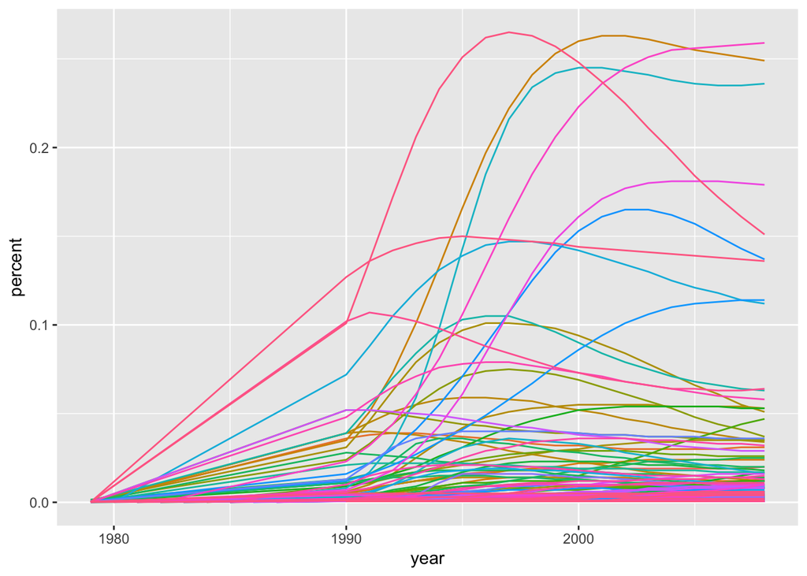

```r
ggplot(hiv_long, aes(x = year, y = percent,
                     group = `Estimated HIV Prevalence% - (Ages 15-49)`,
                     color = `Estimated HIV Prevalence% - (Ages 15-49)`)) +
    geom_line() +
    theme(legend.position = "none")
```

## Pivot Wider

We can also go the other way, for any number of reasons. Let’s say we are working with a colleague who relies on Excel? They will need the data in wide format to graph it or use it.

```r
baby_wide <- babynames %>%
    filter(name %in% c("Jacob", "Lucas", "Elizabeth", "Regina", "Sasha", "Poppy")) %>%
    select(year:n) %>%
    pivot_wider(names_from = year, values_from = n)
baby_wide
```

```
## # A tibble: 11 × 140
##    sex   name     `1880` `1881` `1882` `1883` `1884` `1885` `1886` `1887` `1888`
##    <chr> <chr>     <int>  <int>  <int>  <int>  <int>  <int>  <int>  <int>  <int>
##  1 F     Elizabe…   1939   1852   2186   2255   2549   2582   2680   2681   3224
##  2 F     Regina       36     41     43     38     67     71     69     66     92
##  3 M     Jacob       404    381    390    356    381    343    346    317    353
##  4 M     Elizabe…      9     NA      7     13     16      9     11     14     12
##  5 M     Lucas        NA     11     NA      5      5      6      8     NA      6
##  6 F     Jacob        NA     NA     NA     NA     NA     NA     NA     NA     NA
##  7 M     Regina       NA     NA     NA     NA     NA     NA     NA     NA     NA
##  8 F     Poppy        NA     NA     NA     NA     NA     NA     NA     NA     NA
##  9 F     Sasha        NA     NA     NA     NA     NA     NA     NA     NA     NA
## 10 M     Sasha        NA     NA     NA     NA     NA     NA     NA     NA     NA
## 11 F     Lucas        NA     NA     NA     NA     NA     NA     NA     NA     NA
## # … with 129 more variables: `1889` <int>, `1890` <int>, `1891` <int>,
## #   `1892` <int>, `1893` <int>, `1894` <int>, `1895` <int>, `1896` <int>,
## #   `1897` <int>, `1898` <int>, `1899` <int>, `1900` <int>, `1901` <int>,
## #   `1902` <int>, `1903` <int>, `1904` <int>, `1905` <int>, `1906` <int>,
## #   `1907` <int>, `1908` <int>, `1909` <int>, `1910` <int>, `1911` <int>,
## #   `1912` <int>, `1913` <int>, `1914` <int>, `1915` <int>, `1916` <int>,
## #   `1917` <int>, `1918` <int>, `1919` <int>, `1920` <int>, `1921` <int>, …
```